# Visualization-project-01

[figure not shown]

```r
ggplot(data = oscar_data_3, mapping = aes(x = awards_wins, y = rate)) +
  geom_point() +
    labs(x = "Number of awards", y="IMDb ratings", title = "Plot #3.09") +
  scale_x_continuous (limits = c(0, 50),breaks = seq(0, 50, by = 5)) +
  scale_y_continuous (limits = c(0, 10),breaks = seq(0, 10, by = 1)) +
  guides(color=guide_legend(title="First genre")) +
  geom_smooth(color = "red")
```

Plot #3.08 shows all the movies that won over 30 awards in different ceremonies, had gotten high scores (over 80 out of 100) from critics. According to plot #3.09, the same thing is true regarding number of awards and IMDb ratings.

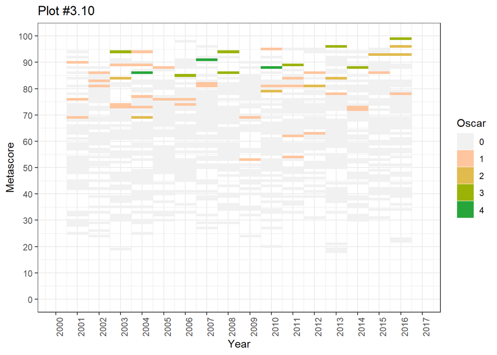

```r
oscar_data_3 %>%
  ggplot(aes(x = year, y = metascore, fill = factor(Oscar_won) )) +
  labs( x = "Year", y="Metascore", title = "Plot #3.10") +
  geom_tile() +
  theme_bw() +
  scale_x_continuous (limits = c(2000, 2017),breaks = seq(2000, 2017, by = 1)) +
  scale_y_continuous (limits = c(0, 100),breaks = seq(0, 100, by = 10)) +
  scale_fill_discrete_sequential(palette = "Terrain")+
  theme(axis.text.x = element_text(angle=90, hjust=1)) +
  guides(fill=guide_legend(title="Oscar"))
```

[figure not shown]

```r
oscar_data_3 %>%
  ggplot(aes(x = year, y = rate, fill = factor(Oscar_won) )) +
  labs( x = "Year", y="IMDb rating", title = "Plot #3.11") +
  geom_tile() +
  theme_bw() +
  scale_x_continuous (limits = c(2000, 2017),breaks = seq(2000, 2017, by = 1)) +
  scale_y_continuous (limits = c(1, 10),breaks = seq(1, 10, by = 1)) +
  scale_fill_discrete_sequential(palette = "Terrain")+
  theme(axis.text.x = element_text(angle=90, hjust=1)) +
  guides(fill=guide_legend(title="Oscar"))
```

[figure not shown]

```r
oscar_data_3 %>%
  ggplot(aes(x = metascore, y = rate, fill = factor(Oscar_won) )) +
  labs( x = "Metascore", y="IMDb rating", title = "Plot #3.12") +
  geom_tile() +
  theme_dark() +
  scale_x_continuous (limits = c(80, 100),breaks = seq(80, 100, by = 1)) +
  scale_y_continuous (limits = c(8, 10),breaks = seq(8, 10, by = 0.2)) +
  scale_fill_discrete_sequential(palette = "Terrain")+
  theme(axis.text.x = element_text(angle=90, hjust=1)) +
  guides(fill=guide_legend(title="Oscar awards"))
```

Plots #3.12 shows the number of Oscar awards does not have a direct relationship with ratings. Movies with high ratings fail to win even one award.

# Conclusion

The data that was used for this project entailed every movie that was nominated for Oscar awards in one of these categories between 2000-2017:

- Best picture
- Best director
- Best actor
- Best actress
- Best supporting actor
- Best supporting actress
- Best adapted screenplay
- Best original screenplay

The analysis was done in three different phases. In **phase #1**, only movies that won at least one award were considered. After the preprocessing step was done, the number of rows reduced from 1183 to 136. During the visualization phase, it was discovered that the jury of Oscar was interested in drama movies more than any other genre. Around 32% of all awards belong to this genre. Even when the first genre of a winner movie was not drama, the second genre probably was. A similar result was observed from a plot that divided the winners into the eight mentioned categories. Biography is the second favorite genre of the Oscar jury.

Looking at the plots related to Oscar winners and certificate of movies, it can be seen that R movies were preferred over others in all categories except best actress. In the best supporting actress category, R moves have a higher number by one point, indicating that women have a better chance to win if they perform in PG-13 rated movies.

There is no apparent relation between the domestic gross and the number of Oscar awards. The number of movies that won just one award is more than the others that won 2,3 or 4 awards and their gross includes a bigger range.

The most interesting finding of this phase is the fact that unlike what is believed, Oscar-winner movies did not always get high scores from people or critics. They are some winners whose scores are considered low.

In **phase #2** the focus was on all the movies that were nominated for Oscar and their gross. Action, adventure, and animation were the genres with the highest gross. Three genres that were not very successful in winning Oscar awards, were the most profitable ones. Plot #2.06 shows the mean gross of every genre and genre family with one movie has the highest gross. But the fact is this movie is an animation, although its first genre identified as family.

**Phase #3** analyzed the nominated movies and their ratings from people (IMDb rating) and critics (Metascore). There is a linear correlation between these two. All the movies that won more than 30 awards have high scores from both groups of viewers. Although the same thing cannot be said about the Oscar-nominated movies. There are movies with very low ratings (less than 3 IMDb rating and less than 20 Metascore rating) that managed to be nominated for Oscar awards.